# **IIMK - Data Science and Artificial Intelligence**

## Project By: Vivek Kulthe

# Project Title: Why Do Employees Quit? *(Employee Attrition Analysis & Prediction)*

# Background:

**Organization Background:**

ABC Technologies, is facing a concerning trend of high employee attrition even though they offer a competitive salary and benefits package.

**Problem Statement:**

This suggests the root cause of attrition lies beyond financial compensation. Company wants to identify the underlying factors driving employee departures to improve retention and maintain a strong talent pool.

**Challenges Faced:**

- Project Delays
- Reputational Damage
- Low Employee Morale
- Recruitement Cost Increase
- Training Cost Increase

# Objective

- Analyze & Visualize the employee data to uncover trends and patterns related to employee attrition
- Identify key attributes associated with departing employees, viz;
  - Demographic factors
  - Compensation and benefits
  - Work environment
  - Job satisfaction
  - Managerial influence
  - Career progression
- Build a regression model to predict if an employee is at a risk of attrition
- Analyze model performance to identify the most significant predictors of attrition

# Importing The Libraries

```python
# Importing sys and os
# OS module is responsible for interacting with the operating system, providing access to the underlying interface of the operating system
# SYS module is responsible for the interaction between the program and the Python interpreter
import sys
import os

# Input data files are available in the read-only "../input/" directory
# For example, running this (by clicking run or pressing Shift+Enter) will list all files under the input directory
for dirname, _, filenames in os.walk('/kaggle/input'):
    for filename in filenames:
        print(os.path.join(dirname, filename))

from google.colab import drive
drive.mount('/content/drive', force_remount=True)

#pd.options.display.max_columns = None

# The warnings filter controls whether warnings are ignored, displayed, or turned into errors (raising an exception)
# 'ignore' = never print matching warnings
import warnings
warnings.filterwarnings('ignore')

import pandas as pd
pd.set_option('display.max_columns', 50)
import numpy as np
import re
from scipy import stats

import seaborn as sns
sns.set(rc = {'figure.figsize' : (14, 10)})
sns.set_style('whitegrid')
sns.color_palette('dark')

import matplotlib as mpl
import matplotlib.pyplot as plt
plt.style.use('fivethirtyeight')
from matplotlib import rcParams
rcParams['lines.linewidth'] = 2
rcParams['xtick.labelsize'] = 'small'
rcParams['ytick.labelsize'] = 'small'
rcParams['axes.labelsize'] = 'medium'
rcParams['axes.titlesize'] = 'medium'
rcParams['axes.titlepad'] = 10.0

import imblearn as im
from imblearn import under_sampling, over_sampling
import sklearn as sk
from sklearn.preprocessing import MinMaxScaler, StandardScaler
from sklearn.metrics import accuracy_score, precision_score, recall_score, f1_score, roc_auc_score, confusion_matrix
from sklearn.model_selection import train_test_split, GridSearchCV, RandomizedSearchCV
from sklearn.linear_model import LogisticRegression
from sklearn.neighbors import KNeighborsClassifier
from sklearn.tree import DecisionTreeClassifier
from sklearn.svm import SVC
from sklearn.ensemble import RandomForestClassifier
from sklearn.ensemble import ExtraTreesClassifier
import xgboost as xgb
from xgboost import XGBClassifier

# check the version
print('python', sys.version)
for pkg in [pd, np, mpl, sns, im, sk, xgb]:
    print(pkg.__name__, pkg.__version__)
```

```
python 3.10.12 (main, Nov 20 2023, 15:14:05) [GCC 11.4.0]
pandas 2.0.3
numpy 1.25.2
matplotlib 3.7.1
seaborn 0.13.1
imblearn 0.10.1
sklearn 1.2.2
xgboost 2.0.3
```

# **O**BTAINING THE DATA

**Reading The File**

```python
gd_path = '/content/drive/MyDrive/Colab Notebooks'
fname = 'dataset/WA_Fn-UseC_-HR-Employee-Attrition.csv'
data = f"{gd_path}/{fname}"
df=pd.read_csv('/content/drive/MyDrive/Colab Notebooks/dataset/WA_Fn-UseC_-HR-Employee-Attrition.csv')
```

**Taking the glance at the data**

```python
# Take a glance at first 10 rows for quickly testing if our object has the right type of data in it
df.head(10)
```

|  | Age | Attrition | BusinessTravel | DailyRate | Department | DistanceFromHome | Education | EducationField | EmployeeCount | EmployeeNumber | EnvironmentSatisfaction | Gender | HourlyRate | JobInvolvement | JobLevel | JobRole | JobSatisfaction | MaritalStatus | MonthlyIncome | MonthlyRate | NumCompaniesWorked | Over18 | OverTime | PercentSalaryHike | PerformanceRating | RelationshipSatisfaction | StandardHours | StockOptionLevel | TotalWorkingYears | … |
| --- | --- | --- | --- | --- | --- | --- | --- | --- | --- | --- | --- | --- | --- | --- | --- | --- | --- | --- | --- | --- | --- | --- | --- | --- | --- | --- | --- | --- | --- | --- |
| 0 | 41 | Yes | Travel_Rarely | 1102 | Sales | 1 | 2 | Life Sciences | 1 | 1 | 2 | Female | 94 | 3 | 2 | Sales Executive | 4 | Single | 5993 | 19479 | 8 | Y | Yes | 11 | 3 | 1 | 80 | 0 | 8 | … |
| 1 | 49 | No | Travel_Frequently | 279 | Research & Development | 8 | 1 | Life Sciences | 1 | 2 | 3 | Male | 61 | 2 | 2 | Research Scientist | 2 | Married | 5130 | 24907 | 1 | Y | No | 23 | 4 | 4 | 80 | 1 | 10 | … |
| 2 | 37 | Yes | Travel_Rarely | 1373 | Research & Development | 2 | 2 | Other | 1 | 4 | 4 | Male | 92 | 2 | 1 | Laboratory Technician | 3 | Single | 2090 | 2396 | 6 | Y | Yes | 15 | 3 | 2 | 80 | 0 | 7 | … |
| 3 | 33 | No | Travel_Frequently | 1392 | Research & Development | 3 | 4 | Life Sciences | 1 | 5 | 4 | Female | 56 | 3 | 1 | Research Scientist | 3 | Married | 2909 | 23159 | 1 | Y | Yes | 11 | 3 | 3 | 80 | 0 | 8 | … |
| 4 | 27 | No | Travel_Rarely | 591 | Research & Development | 2 | 1 | Medical | 1 | 7 | 1 | Male | 40 | 3 | 1 | Laboratory Technician | 2 | Married | 3468 | 16632 | 9 | Y | No | 12 | 3 | 4 | 80 | 1 | 6 | … |
| 5 | 32 | No | Travel_Frequently | 1005 | Research & Development | 2 | 2 | Life Sciences | 1 | 8 | 4 | Male | 79 | 3 | 1 | Laboratory Technician | 4 | Single | 3068 | 11864 | 0 | Y | No | 13 | 3 | 3 | 80 | 0 | 8 | … |
| 6 | 59 | No | Travel_Rarely | 1324 | Research & Development | 3 | 3 | Medical | 1 | 10 | 3 | Female | 81 | 4 | 1 | Laboratory Technician | 1 | Married | 2670 | 9964 | 4 | Y | Yes | 20 | 4 | 1 | 80 | 3 | 12 | … |
| 7 | 30 | No | Travel_Rarely | 1358 | Research & Development | 24 | 1 | Life Sciences | 1 | 11 | 4 | Male | 67 | 3 | 1 | Laboratory Technician | 3 | Divorced | 2693 | 13335 | 1 | Y | No | 22 | 4 | 2 | 80 | 1 | 1 | … |
| 8 | 38 | No | Travel_Frequently | 216 | Research & Development | 23 | 3 | Life Sciences | 1 | 12 | 4 | Male | 44 | 2 | 3 | Manufacturing Director | 3 | Single | 9526 | 8787 | 0 | Y | No | 21 | 4 | 2 | 80 | 0 | 10 | … |
| 9 | 36 | No | Travel_Rarely | 1299 | Research & Development | 27 | 3 | Medical | 1 | 13 | 3 | Male | 94 | 3 | 2 | Healthcare Representative | 3 | Married | 5237 | 16577 | 6 | Y | No | 13 | 3 | 2 | 80 | 2 | 17 | … |

```python
# create a backup of original dataset for future use
df_raw = df.copy()
```

**Understanding The Dataframe**

```python
# Let's see number of columns, column labels, column data types, memory usage, range index, and non-null information about DataFrame
df.info()
```

```
<class 'pandas.core.frame.DataFrame'>
RangeIndex: 1470 entries, 0 to 1469
Data columns (total 35 columns):
 #   Column                    Non-Null Count  Dtype
---  ------                    --------------  -----
 0   Age                       1470 non-null   int64
 1   Attrition                 1470 non-null   object
 2   BusinessTravel            1470 non-null   object
 3   DailyRate                 1470 non-null   int64
 4   Department                1470 non-null   object
 5   DistanceFromHome          1470 non-null   int64
 6   Education                 1470 non-null   int64
 7   EducationField            1470 non-null   object
 8   EmployeeCount             1470 non-null   int64
 9   EmployeeNumber            1470 non-null   int64
```

[output cut: 27 more lines]

From the information above, we can know that:

- The dataset has a total of 35 columns and 1470 rows
- There are no *null* or *missing values* in each column
- The `attrition` column is a classification target with the data type `object`
- The other columns are *feature* with data types `int64` (26 columns) and `object` (8 columns)

## Data Mining (Rethink On Title)

### Qualitative Data Types

#### Nominal Data Types (Identify & Mark)

```python
# Qualitative - Nominal (N)
qual_n = [
    'Attrition', # target
    'BusinessTravel',
    'Department',
    'EducationField',
    'EmployeeNumber', # id
    'Gender',
    'JobRole',
    'MaritalStatus',
    'Over18',
    'OverTime',
]
```

#### Ordinal Data Types (Identify & Mark)

```python
# Qualitative - Ordinal (O)

qual_o = [
    'Education', # desc
    'EnvironmentSatisfaction', # desc
    'JobInvolvement', # desc
    'JobLevel',
    'JobSatisfaction', # desc
    'PerformanceRating', # desc
    'RelationshipSatisfaction', # desc
    'StockOptionLevel',
    'WorkLifeBalance', # desc
]
```

```python
#Combined Qualitative Data Set (Nominal + Ordinal)
qual = qual_n + qual_o
df_qual = df[qual]
df_qual.head(10)
```

|  | Attrition | BusinessTravel | Department | EducationField | EmployeeNumber | Gender | JobRole | MaritalStatus | Over18 | OverTime | Education | EnvironmentSatisfaction | JobInvolvement | JobLevel | JobSatisfaction | PerformanceRating | RelationshipSatisfaction | StockOptionLevel | WorkLifeBalance |
| --- | --- | --- | --- | --- | --- | --- | --- | --- | --- | --- | --- | --- | --- | --- | --- | --- | --- | --- | --- |
| 0 | Yes | Travel_Rarely | Sales | Life Sciences | 1 | Female | Sales Executive | Single | Y | Yes | 2 | 2 | 3 | 2 | 4 | 3 | 1 | 0 | 1 |
| 1 | No | Travel_Frequently | Research & Development | Life Sciences | 2 | Male | Research Scientist | Married | Y | No | 1 | 3 | 2 | 2 | 2 | 4 | 4 | 1 | 3 |
| 2 | Yes | Travel_Rarely | Research & Development | Other | 4 | Male | Laboratory Technician | Single | Y | Yes | 2 | 4 | 2 | 1 | 3 | 3 | 2 | 0 | 3 |
| 3 | No | Travel_Frequently | Research & Development | Life Sciences | 5 | Female | Research Scientist | Married | Y | Yes | 4 | 4 | 3 | 1 | 3 | 3 | 3 | 0 | 3 |
| 4 | No | Travel_Rarely | Research & Development | Medical | 7 | Male | Laboratory Technician | Married | Y | No | 1 | 1 | 3 | 1 | 2 | 3 | 4 | 1 | 3 |
| 5 | No | Travel_Frequently | Research & Development | Life Sciences | 8 | Male | Laboratory Technician | Single | Y | No | 2 | 4 | 3 | 1 | 4 | 3 | 3 | 0 | 2 |
| 6 | No | Travel_Rarely | Research & Development | Medical | 10 | Female | Laboratory Technician | Married | Y | Yes | 3 | 3 | 4 | 1 | 1 | 4 | 1 | 3 | 2 |
| 7 | No | Travel_Rarely | Research & Development | Life Sciences | 11 | Male | Laboratory Technician | Divorced | Y | No | 1 | 4 | 3 | 1 | 3 | 4 | 2 | 1 | 3 |
| 8 | No | Travel_Frequently | Research & Development | Life Sciences | 12 | Male | Manufacturing Director | Single | Y | No | 3 | 4 | 2 | 3 | 3 | 4 | 2 | 0 | 3 |
| 9 | No | Travel_Rarely | Research & Development | Medical | 13 | Male | Healthcare Representative | Married | Y | No | 3 | 3 | 3 | 2 | 3 | 3 | 2 | 2 | 2 |

```python
# Let's check the data types for identified Nominal Data
df[qual_n].dtypes
```

```
Attrition         object
BusinessTravel    object
Department        object
EducationField    object
EmployeeNumber     int64
Gender            object
JobRole           object
MaritalStatus     object
Over18            object
OverTime          object
dtype: object
```

```python
# Let's check the data types for identified Ordinal Data (if there is need to decode the columns)
df[qual_o].dtypes
```

```
Education                   int64
EnvironmentSatisfaction     int64
JobInvolvement              int64
JobLevel                    int64
JobSatisfaction             int64
PerformanceRating           int64
RelationshipSatisfaction    int64
StockOptionLevel            int64
WorkLifeBalance             int64
dtype: object
```

```python
df[qual].dtypes
```

```
Attrition                   object
BusinessTravel              object
Department                  object
EducationField              object
EmployeeNumber               int64
Gender                      object
JobRole                     object
MaritalStatus               object
Over18                      object
OverTime                    object
Education                    int64
EnvironmentSatisfaction      int64
JobInvolvement               int64
JobLevel                     int64
JobSatisfaction              int64
PerformanceRating            int64
RelationshipSatisfaction     int64
StockOptionLevel             int64
WorkLifeBalance              int64
dtype: object
```

### Quantitative Data Types

#### Interval Data Types (Identify & Mark)

```python
# Quantitative - Interval (I)
quant_i = [
    'Age',
    'DistanceFromHome',
    'EmployeeCount', # 1
    'NumCompaniesWorked',
    'StandardHours', # 1
    'TrainingTimesLastYear'
]
```

#### Ratio Data Types (Identify & Mark)

```python
# Quantitative Ratio (R)
quant_r = [
    'DailyRate',
    'HourlyRate',
    'MonthlyRate',
    'PercentSalaryHike', # percentage
    'TotalWorkingYears',
    'MonthlyIncome',
    'YearsAtCompany',
    'YearsInCurrentRole',
    'YearsSinceLastPromotion',
    'YearsWithCurrManager'
]
```

```python
quant = quant_i + quant_r
df_quant = df[quant]
df_quant.head(3)
```

|  | Age | DistanceFromHome | EmployeeCount | NumCompaniesWorked | StandardHours | TrainingTimesLastYear | DailyRate | HourlyRate | MonthlyRate | PercentSalaryHike | TotalWorkingYears | MonthlyIncome | YearsAtCompany | YearsInCurrentRole | YearsSinceLastPromotion | YearsWithCurrManager |
| --- | --- | --- | --- | --- | --- | --- | --- | --- | --- | --- | --- | --- | --- | --- | --- | --- |
| 0 | 41 | 1 | 1 | 8 | 80 | 0 | 1102 | 94 | 19479 | 11 | 8 | 5993 | 6 | 4 | 0 | 5 |
| 1 | 49 | 8 | 1 | 1 | 80 | 3 | 279 | 61 | 24907 | 23 | 10 | 5130 | 10 | 7 | 1 | 7 |
| 2 | 37 | 2 | 1 | 6 | 80 | 3 | 1373 | 92 | 2396 | 15 | 7 | 2090 | 0 | 0 | 0 | 0 |

# Data Cleansing

```python
# copying the raw dataset
df_clean = df_raw.copy()
```

- `df_raw` = raw dataset
- `df_clean` = dataset that has been cleaned (drop columns, drop rows, encoding, etc.)

Note: Use `df_clean` if you want to carry out a cleansing process so that the raw data retains its value.

## Handling Single & Unique Data

Note:

- Single data in question is a column that has only 1 unique value.
- Unique data in question is a column whose entire row contains a unique value (such as `employee number`).

```python
df_clean.nunique()
```

```
Age                           43
Attrition                      2
BusinessTravel                 3
DailyRate                    886
Department                     3
DistanceFromHome              29
Education                      5
EducationField                 6
EmployeeCount                  1
EmployeeNumber              1470
EnvironmentSatisfaction        4
Gender                         2
HourlyRate                    71
JobInvolvement                 4
JobLevel                       5
JobRole                        9
JobSatisfaction                4
MaritalStatus                  3
MonthlyIncome               1349
MonthlyRate                 1427
NumCompaniesWorked            10
Over18                         1
OverTime                       2
PercentSalaryHike             15
PerformanceRating              2
RelationshipSatisfaction       4
StandardHours                  1
StockOptionLevel               4
TotalWorkingYears             40
TrainingTimesLastYear          7
WorkLifeBalance                4
YearsAtCompany                37
YearsInCurrentRole            19
YearsSinceLastPromotion       16
YearsWithCurrManager          18
dtype: int64
```

Observation:

- `EmployeeCount`, `Over18`, `StandardHours` are columns that only have 1 unique value.
- `EmployeeNumber` is a column whose entire row contains a unique value.

```python
bef = len(df_clean.columns) # number of columns before removal
df_clean = df_clean.drop(['EmployeeCount', 'Over18', 'StandardHours', 'EmployeeNumber'], axis = 1) # columns dropped
aft = len(df_clean.columns) # number of columns after removal
print(f"The number of columns are reduced from {bef} to {aft}.")
```

[output not shown]

Observation:

- The number of columns are reduced from 35 to 31

## Handling Missing Data

```python
df_clean.isnull().sum()
```

```
Age                         0
Attrition                   0
BusinessTravel              0
DailyRate                   0
Department                  0
DistanceFromHome            0
Education                   0
EducationField              0
EnvironmentSatisfaction     0
Gender                      0
HourlyRate                  0
JobInvolvement              0
JobLevel                    0
JobRole                     0
JobSatisfaction             0
MaritalStatus               0
MonthlyIncome               0
MonthlyRate                 0
NumCompaniesWorked          0
OverTime                    0
PercentSalaryHike           0
PerformanceRating           0
RelationshipSatisfaction    0
StockOptionLevel            0
TotalWorkingYears           0
TrainingTimesLastYear       0
WorkLifeBalance             0
YearsAtCompany              0
YearsInCurrentRole          0
YearsSinceLastPromotion     0
YearsWithCurrManager        0
dtype: int64
```

Observation:

- There is no empty (null) data in any column in the dataframe

## Handling Duplicated Data

```python
df_clean.duplicated().sum()
```

```
0
```

Observation:

- There are no duplicates in each column

## Handling Outliers

```python
df_quant.describe()
```

|  | Age | DistanceFromHome | EmployeeCount | NumCompaniesWorked | StandardHours | TrainingTimesLastYear | DailyRate | HourlyRate | MonthlyRate | PercentSalaryHike | TotalWorkingYears | MonthlyIncome | YearsAtCompany | YearsInCurrentRole | YearsSinceLastPromotion | YearsWithCurrManager |
| --- | --- | --- | --- | --- | --- | --- | --- | --- | --- | --- | --- | --- | --- | --- | --- | --- |
| count | 1470.000000 | 1470.000000 | 1470.0 | 1470.000000 | 1470.0 | 1470.000000 | 1470.000000 | 1470.000000 | 1470.000000 | 1470.000000 | 1470.000000 | 1470.000000 | 1470.000000 | 1470.000000 | 1470.000000 | 1470.000000 |
| mean | 36.923810 | 9.192517 | 1.0 | 2.693197 | 80.0 | 2.799320 | 802.485714 | 65.891156 | 14313.103401 | 15.209524 | 11.279592 | 6502.931293 | 7.008163 | 4.229252 | 2.187755 | 4.123129 |
| std | 9.135373 | 8.106864 | 0.0 | 2.498009 | 0.0 | 1.289271 | 403.509100 | 20.329428 | 7117.786044 | 3.659938 | 7.780782 | 4707.956783 | 6.126525 | 3.623137 | 3.222430 | 3.568136 |
| min | 18.000000 | 1.000000 | 1.0 | 0.000000 | 80.0 | 0.000000 | 102.000000 | 30.000000 | 2094.000000 | 11.000000 | 0.000000 | 1009.000000 | 0.000000 | 0.000000 | 0.000000 | 0.000000 |
| 25% | 30.000000 | 2.000000 | 1.0 | 1.000000 | 80.0 | 2.000000 | 465.000000 | 48.000000 | 8047.000000 | 12.000000 | 6.000000 | 2911.000000 | 3.000000 | 2.000000 | 0.000000 | 2.000000 |
| 50% | 36.000000 | 7.000000 | 1.0 | 2.000000 | 80.0 | 3.000000 | 802.000000 | 66.000000 | 14235.500000 | 14.000000 | 10.000000 | 4919.000000 | 5.000000 | 3.000000 | 1.000000 | 3.000000 |
| 75% | 43.000000 | 14.000000 | 1.0 | 4.000000 | 80.0 | 3.000000 | 1157.000000 | 83.750000 | 20461.500000 | 18.000000 | 15.000000 | 8379.000000 | 9.000000 | 7.000000 | 3.000000 | 7.000000 |
| max | 60.000000 | 29.000000 | 1.0 | 9.000000 | 80.0 | 6.000000 | 1499.000000 | 100.000000 | 26999.000000 | 25.000000 | 40.000000 | 19999.000000 | 40.000000 | 18.000000 | 15.000000 | 17.000000 |

```python
df_quant.shape[0]
```

```
1470
```

```python
# column from which outliers will be removed
cols = ['TotalWorkingYears', 'TrainingTimesLastYear', 'YearsAtCompany', 'YearsInCurrentRole', 'YearsSinceLastPromotion', 'YearsWithCurrManager', 'MonthlyIncome']
```

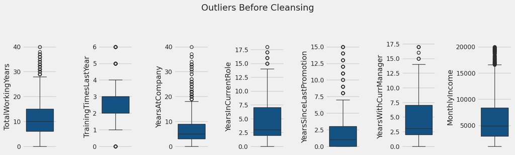

```python
# Before
plt.figure(figsize = (14, 4))
for i in range(0, len(cols)):
    plt.subplot(1, 7, i+1)
    sns.boxplot(y = df_clean[cols[i]], color = '#005495', orient = 'v')

plt.suptitle('Outliers Before Cleansing', y = 1.05)
plt.tight_layout(pad = 1.5)
plt.show()
```

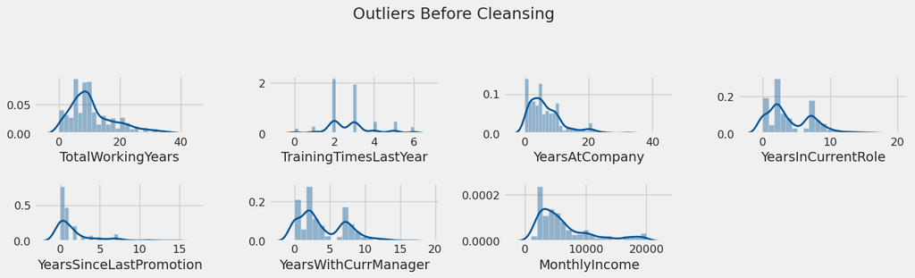

```python
# Sebelum
plt.figure(figsize = (14, 4))
for i in range(0, len(cols)):
    plt.subplot(2, 4, i+1)
    sns.distplot(df_clean[cols[i]], color = '#005495')
    plt.ylabel('')

plt.suptitle('Outliers Before Cleansing', y = 1.05)
plt.tight_layout(pad = 1.5)
plt.show()
```

### Z-Score Method

```python
print(f'Number of rows before removing outliers: {len(df_clean)}')

filtered_entries = np.array([True] * len(df_clean))

for col in cols:
    zscore = abs(stats.zscore(df_clean[col])) # calculate the absolute z-score
    filtered_entries = (zscore < 3) & filtered_entries # keep less than 3 absolute z-scores

df_ZSCORE = df_clean[filtered_entries] # filter, only take those whose z-score is below 3

print(f'Number of rows after removing outliers: {len(df_ZSCORE)}')
```

```
Number of rows before removing outliers: 1470
Number of rows after removing outliers: 1387
```

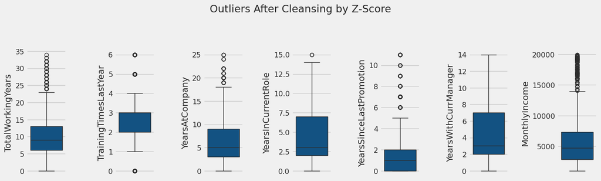

```python
# After using Z-SCORE
plt.figure(figsize = (14, 4))
for i in range(0, len(cols)):
    plt.subplot(1, 7, i+1)
    sns.boxplot(y = df_ZSCORE[cols[i]], color = '#005495', orient = 'v')

plt.suptitle('Outliers After Cleansing by Z-Score', y = 1.05)
plt.tight_layout(pad = 1.5)
plt.show()
```

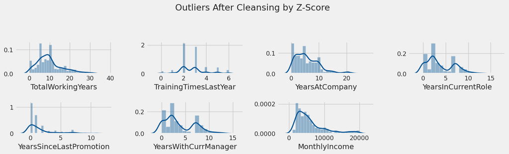

```python
# After using Z-SCORE
plt.figure(figsize = (14, 4))
for i in range(0, len(cols)):
    plt.subplot(2, 4, i+1)
    sns.distplot(df_ZSCORE[cols[i]], color = '#005495')
    plt.ylabel('')

plt.suptitle('Outliers After Cleansing by Z-Score', y = 1.05)
plt.tight_layout(pad = 1.5)
plt.show()
```

### IQR (Inter-Quartile Range) Method

```python
print(f'Number of rows before removing outliers: {len(df_clean)}')

filtered_entries = np.array([True] * len(df_clean))
for col in cols:
    Q1 = df_clean[col].quantile(0.25)
    Q3 = df_clean[col].quantile(0.75)
    IQR = Q3 - Q1
    low_limit = Q1 - (IQR * 1.5)
    high_limit = Q3 + (IQR * 1.5)

    filtered_entries = ((df_clean[col] >= low_limit) & (df_clean[col] <= high_limit)) & filtered_entries

df_IQR = df_clean[filtered_entries]

print(f'Number of rows after removing outliers: {len(df_IQR)}')
```

```
Number of rows before removing outliers: 1470
Number of rows after removing outliers: 1024
```

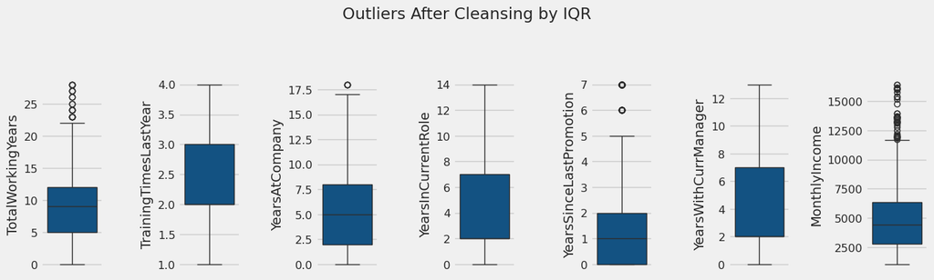

```python
# After using IQR
plt.figure(figsize = (14, 4))
for i in range(0, len(cols)):
    plt.subplot(1, 7, i+1)
    sns.boxplot(y = df_IQR[cols[i]], color = '#005495', orient = 'v')

plt.suptitle('Outliers After Cleansing by IQR', y = 1.05)
plt.tight_layout(pad = 1.5)
plt.show()
```

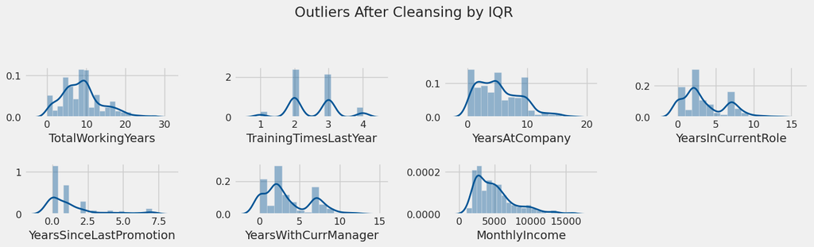

```python
# After using IQR
plt.figure(figsize = (14, 4))
for i in range(0, len(cols)):
    plt.subplot(2, 4, i+1)
    sns.distplot(df_IQR[cols[i]], color = '#005495')
    plt.ylabel('')

plt.suptitle('Outliers After Cleansing by IQR', y = 1.05)
plt.tight_layout(pad = 1.5)
plt.show()
```

### Result

Z-Score

- Number of rows before removing outliers: 1470
- Number of rows after removing outliers: 1387
- Number of rows removed: 83

IQR

- Number of rows before removing outliers: 1470
- Number of rows after removing outliers: 1024
- Number of rows removed: 446

Observation:

- Z-Score Method is more suitable because IQR is removing lot of data from the dataset.

```python
df_clean = df_ZSCORE.copy()
df_clean.head()
```

|  | Age | Attrition | BusinessTravel | DailyRate | Department | DistanceFromHome | Education | EducationField | EnvironmentSatisfaction | Gender | HourlyRate | JobInvolvement | JobLevel | JobRole | JobSatisfaction | MaritalStatus | MonthlyIncome | MonthlyRate | NumCompaniesWorked | OverTime | PercentSalaryHike | PerformanceRating | RelationshipSatisfaction | StockOptionLevel | TotalWorkingYears | TrainingTimesLastYear | WorkLifeBalance | YearsAtCompany | YearsInCurrentRole | … |
| --- | --- | --- | --- | --- | --- | --- | --- | --- | --- | --- | --- | --- | --- | --- | --- | --- | --- | --- | --- | --- | --- | --- | --- | --- | --- | --- | --- | --- | --- | --- |
| 0 | 41 | Yes | Travel_Rarely | 1102 | Sales | 1 | 2 | Life Sciences | 2 | Female | 94 | 3 | 2 | Sales Executive | 4 | Single | 5993 | 19479 | 8 | Yes | 11 | 3 | 1 | 0 | 8 | 0 | 1 | 6 | 4 | … |
| 1 | 49 | No | Travel_Frequently | 279 | Research & Development | 8 | 1 | Life Sciences | 3 | Male | 61 | 2 | 2 | Research Scientist | 2 | Married | 5130 | 24907 | 1 | No | 23 | 4 | 4 | 1 | 10 | 3 | 3 | 10 | 7 | … |
| 2 | 37 | Yes | Travel_Rarely | 1373 | Research & Development | 2 | 2 | Other | 4 | Male | 92 | 2 | 1 | Laboratory Technician | 3 | Single | 2090 | 2396 | 6 | Yes | 15 | 3 | 2 | 0 | 7 | 3 | 3 | 0 | 0 | … |
| 3 | 33 | No | Travel_Frequently | 1392 | Research & Development | 3 | 4 | Life Sciences | 4 | Female | 56 | 3 | 1 | Research Scientist | 3 | Married | 2909 | 23159 | 1 | Yes | 11 | 3 | 3 | 0 | 8 | 3 | 3 | 8 | 7 | … |
| 4 | 27 | No | Travel_Rarely | 591 | Research & Development | 2 | 1 | Medical | 1 | Male | 40 | 3 | 1 | Laboratory Technician | 2 | Married | 3468 | 16632 | 9 | No | 12 | 3 | 4 | 1 | 6 | 3 | 3 | 2 | 2 | … |

# Feature Engineering

## Create New Features

```python
# Add "Group Age" Feature
df_clean['GroupAge'] = np.where(df_clean['Age'] <= 30, '18-30',
                                np.where((df_clean['Age'] > 30) & (df_clean['Age'] <= 40), '31-40',
                                         np.where((df_clean['Age'] > 40) & (df_clean['Age'] <= 50), '41-50', '51-60')))
df_clean[['Age', 'GroupAge']]
```

|  | Age | GroupAge |
| --- | --- | --- |
| 0 | 41 | 41-50 |
| 1 | 49 | 41-50 |
| 2 | 37 | 31-40 |
| 3 | 33 | 31-40 |
| 4 | 27 | 18-30 |
| ... | ... | ... |
| 1465 | 36 | 31-40 |
| 1466 | 39 | 31-40 |
| 1467 | 27 | 18-30 |
| 1468 | 49 | 41-50 |
| 1469 | 34 | 31-40 |

1387 rows × 2 columns

```python
# Median Monthly Income By Job Level
MedIncome = df_clean.groupby(['JobLevel'])['MonthlyIncome'].median()
MedIncome
```

```
JobLevel
1     2661.5
2     5343.0
3     9852.0
4    15992.0
5    19174.0
Name: MonthlyIncome, dtype: float64
```

```python
# Add Feature Median Monthly Income By Job Level (below == 1, above == 0)
df_clean['BelowMedIncome'] = df_clean['JobLevel'].apply(lambda x: MedIncome[x])
df_clean['BelowMedIncome'] = np.where(df_clean['MonthlyIncome'] < df_clean['BelowMedIncome'], 1, 0)
```

```python
# added group age (18-30) & overtime (yes) features
df_clean['GroupAge_Overtime'] = np.where((df_clean['GroupAge'] == '18-30') & (df_clean['OverTime'] == 'Yes'), 1, 0)

# added job level (1) & overtime (yes) features
df_clean['JobLevel_Overtime'] = np.where((df_clean['JobLevel'] == 1) & (df_clean['OverTime'] == 'Yes'), 1, 0)

# added job level (1) & below median monthly income (1) & overtime (yes)
df_clean['JobLevel_BelowMedIncome_Overtime'] = np.where((df_clean['JobLevel'] == 1) & (df_clean['BelowMedIncome'] == 1) & (df_clean['OverTime'] == 'Yes'), 1, 0)
```

```python
df_clean
```

|  | Age | Attrition | BusinessTravel | DailyRate | Department | DistanceFromHome | Education | EducationField | EnvironmentSatisfaction | Gender | HourlyRate | JobInvolvement | JobLevel | JobRole | JobSatisfaction | MaritalStatus | MonthlyIncome | MonthlyRate | NumCompaniesWorked | OverTime | PercentSalaryHike | PerformanceRating | RelationshipSatisfaction | StockOptionLevel | TotalWorkingYears | TrainingTimesLastYear | WorkLifeBalance | YearsAtCompany | YearsInCurrentRole | … |
| --- | --- | --- | --- | --- | --- | --- | --- | --- | --- | --- | --- | --- | --- | --- | --- | --- | --- | --- | --- | --- | --- | --- | --- | --- | --- | --- | --- | --- | --- | --- |
| 0 | 41 | Yes | Travel_Rarely | 1102 | Sales | 1 | 2 | Life Sciences | 2 | Female | 94 | 3 | 2 | Sales Executive | 4 | Single | 5993 | 19479 | 8 | Yes | 11 | 3 | 1 | 0 | 8 | 0 | 1 | 6 | 4 | … |
| 1 | 49 | No | Travel_Frequently | 279 | Research & Development | 8 | 1 | Life Sciences | 3 | Male | 61 | 2 | 2 | Research Scientist | 2 | Married | 5130 | 24907 | 1 | No | 23 | 4 | 4 | 1 | 10 | 3 | 3 | 10 | 7 | … |
| 2 | 37 | Yes | Travel_Rarely | 1373 | Research & Development | 2 | 2 | Other | 4 | Male | 92 | 2 | 1 | Laboratory Technician | 3 | Single | 2090 | 2396 | 6 | Yes | 15 | 3 | 2 | 0 | 7 | 3 | 3 | 0 | 0 | … |
| 3 | 33 | No | Travel_Frequently | 1392 | Research & Development | 3 | 4 | Life Sciences | 4 | Female | 56 | 3 | 1 | Research Scientist | 3 | Married | 2909 | 23159 | 1 | Yes | 11 | 3 | 3 | 0 | 8 | 3 | 3 | 8 | 7 | … |
| 4 | 27 | No | Travel_Rarely | 591 | Research & Development | 2 | 1 | Medical | 1 | Male | 40 | 3 | 1 | Laboratory Technician | 2 | Married | 3468 | 16632 | 9 | No | 12 | 3 | 4 | 1 | 6 | 3 | 3 | 2 | 2 | … |
| ... | ... | ... | ... | ... | ... | ... | ... | ... | ... | ... | ... | ... | ... | ... | ... | ... | ... | ... | ... | ... | ... | ... | ... | ... | ... | ... | ... | ... | ... | … |
| 1465 | 36 | No | Travel_Frequently | 884 | Research & Development | 23 | 2 | Medical | 3 | Male | 41 | 4 | 2 | Laboratory Technician | 4 | Married | 2571 | 12290 | 4 | No | 17 | 3 | 3 | 1 | 17 | 3 | 3 | 5 | 2 | … |
| 1466 | 39 | No | Travel_Rarely | 613 | Research & Development | 6 | 1 | Medical | 4 | Male | 42 | 2 | 3 | Healthcare Representative | 1 | Married | 9991 | 21457 | 4 | No | 15 | 3 | 1 | 1 | 9 | 5 | 3 | 7 | 7 | … |
| 1467 | 27 | No | Travel_Rarely | 155 | Research & Development | 4 | 3 | Life Sciences | 2 | Male | 87 | 4 | 2 | Manufacturing Director | 2 | Married | 6142 | 5174 | 1 | Yes | 20 | 4 | 2 | 1 | 6 | 0 | 3 | 6 | 2 | … |
| 1468 | 49 | No | Travel_Frequently | 1023 | Sales | 2 | 3 | Medical | 4 | Male | 63 | 2 | 2 | Sales Executive | 2 | Married | 5390 | 13243 | 2 | No | 14 | 3 | 4 | 0 | 17 | 3 | 2 | 9 | 6 | … |
| 1469 | 34 | No | Travel_Rarely | 628 | Research & Development | 8 | 3 | Medical | 2 | Male | 82 | 4 | 2 | Laboratory Technician | 3 | Married | 4404 | 10228 | 2 | No | 12 | 3 | 1 | 0 | 6 | 3 | 4 | 4 | 3 | … |

1387 rows × 36 columns

## Normalization/Standardization (CHECK IF CAN BE SKIPPED)

*Perform standardization if the numeric feature has a normal distribution, if not, then use normalization.*

```python
# save data for simulation
df_simulation = df_clean.copy()
df_simulation.to_csv(f"{gd_path}/dataset/data_valid_all_sim.csv", index = False)
```

```python
# standardization scaling
std_cols = ['Age']
for col in std_cols:
    x = df_clean[col].values.reshape(len(df_clean), 1)
    scaler = StandardScaler()
    scaler.fit(x)
    x_scaled = scaler.transform(x)
    df_clean[col] = x_scaled

# normalization scaling
nrm_cols = ['DailyRate', 'DistanceFromHome', 'HourlyRate', 'MonthlyIncome', 'MonthlyRate', 'NumCompaniesWorked', 'PercentSalaryHike', 'TotalWorkingYears', 'TrainingTimesLastYear', 'YearsAtCompany', 'YearsInCurrentRole', 'YearsSinceLastPromotion', 'YearsWithCurrManager']
for col in nrm_cols:
    x = df_clean[col].values.reshape(len(df_clean), 1)
    scaler = MinMaxScaler()
    scaler.fit(x)
    x_scaled = scaler.transform(x)
    df_clean[col] = x_scaled

df_clean[std_cols + nrm_cols].head()
```

|  | Age | DailyRate | DistanceFromHome | HourlyRate | MonthlyIncome | MonthlyRate | NumCompaniesWorked | PercentSalaryHike | TotalWorkingYears | TrainingTimesLastYear | YearsAtCompany | YearsInCurrentRole | YearsSinceLastPromotion | YearsWithCurrManager |
| --- | --- | --- | --- | --- | --- | --- | --- | --- | --- | --- | --- | --- | --- | --- |
| 0 | 0.536681 | 0.716332 | 0.000000 | 0.914286 | 0.263230 | 0.698016 | 0.888889 | 0.000000 | 0.235294 | 0.0 | 0.24 | 0.266667 | 0.000000 | 0.357143 |
| 1 | 1.442111 | 0.126791 | 0.250000 | 0.442857 | 0.217651 | 0.915991 | 0.111111 | 0.857143 | 0.294118 | 0.5 | 0.40 | 0.466667 | 0.090909 | 0.500000 |
| 2 | 0.083966 | 0.910458 | 0.035714 | 0.885714 | 0.057093 | 0.012007 | 0.666667 | 0.285714 | 0.205882 | 0.5 | 0.00 | 0.000000 | 0.000000 | 0.000000 |
| 3 | -0.368749 | 0.924069 | 0.071429 | 0.371429 | 0.100349 | 0.845796 | 0.111111 | 0.000000 | 0.235294 | 0.5 | 0.32 | 0.466667 | 0.272727 | 0.000000 |
| 4 | -1.047821 | 0.350287 | 0.035714 | 0.142857 | 0.129872 | 0.583688 | 1.000000 | 0.071429 | 0.176471 | 0.5 | 0.08 | 0.133333 | 0.181818 | 0.142857 |

## Feature Encoding

*Determine the categorical features that need to be labeled normally (0, 1, etc.) or by one-hot encoding.*

```python
# traditional labeling
label_cols = ['Attrition', 'OverTime', 'Gender', 'PerformanceRating']
df_clean['Attrition'] = df_clean['Attrition'].map({'No' : 0, 'Yes' : 1})
df_clean['OverTime'] = df_clean['OverTime'].map({'No' : 0, 'Yes' : 1})
df_clean['Gender'] = df_clean['Gender'].map({'Female' : 0, 'Male' : 1})
df_clean['PerformanceRating'] = df_clean['PerformanceRating'].map({3 : 0, 4 : 1}) # only consist of 2 unique values

# one-hot encoding
onehot_cols = ['BusinessTravel', 'Department', 'EducationField', 'JobRole', 'MaritalStatus', 'Education', 'EnvironmentSatisfaction', 'JobInvolvement', 'JobLevel', 'JobSatisfaction', 'RelationshipSatisfaction', 'StockOptionLevel', 'WorkLifeBalance', 'GroupAge']
result_cols = []
for col in onehot_cols:
    onehot = pd.get_dummies(df_clean[col], prefix = col)
    dummies_cols = list(onehot.columns)
    result_cols = result_cols + dummies_cols
    df_clean = df_clean.join(onehot)
df_clean = df_clean.drop(onehot_cols, axis = 1)

df_clean[label_cols + result_cols].head()
```

|  | Attrition | OverTime | Gender | PerformanceRating | BusinessTravel_Non-Travel | BusinessTravel_Travel_Frequently | BusinessTravel_Travel_Rarely | Department_Human Resources | Department_Research & Development | Department_Sales | EducationField_Human Resources | EducationField_Life Sciences | EducationField_Marketing | EducationField_Medical | EducationField_Other | EducationField_Technical Degree | JobRole_Healthcare Representative | JobRole_Human Resources | JobRole_Laboratory Technician | JobRole_Manager | JobRole_Manufacturing Director | JobRole_Research Director | JobRole_Research Scientist | JobRole_Sales Executive | JobRole_Sales Representative | ... | JobLevel_1 | JobLevel_2 | JobLevel_3 | … |
| --- | --- | --- | --- | --- | --- | --- | --- | --- | --- | --- | --- | --- | --- | --- | --- | --- | --- | --- | --- | --- | --- | --- | --- | --- | --- | --- | --- | --- | --- | --- |
| 0 | 1 | 1 | 0 | 0 | False | False | True | False | False | True | False | True | False | False | False | False | False | False | False | False | False | False | False | True | False | ... | False | True | False | … |
| 1 | 0 | 0 | 1 | 1 | False | True | False | False | True | False | False | True | False | False | False | False | False | False | False | False | False | False | True | False | False | ... | False | True | False | … |
| 2 | 1 | 1 | 1 | 0 | False | False | True | False | True | False | False | False | False | False | True | False | False | False | True | False | False | False | False | False | False | ... | True | False | False | … |
| 3 | 0 | 1 | 0 | 0 | False | True | False | False | True | False | False | True | False | False | False | False | False | False | False | False | False | False | True | False | False | ... | True | False | False | … |
| 4 | 0 | 0 | 1 | 0 | False | False | True | False | True | False | False | False | False | True | False | False | False | False | True | False | False | False | False | False | False | ... | True | False | False | … |

5 rows × 66 columns

## Split Unseen Data

```python
x = df_clean.drop(['Attrition'], axis = 1) # features
y = df_clean[['Attrition']] # target

# train = training data for modeling
# test = unseen data for validation
x_train, x_test, y_train, y_test = train_test_split(x, y, test_size = 0.1, random_state = 42)
```

```python
df_clean = pd.DataFrame(y_train).join(x_train)
df_unseen = pd.DataFrame(y_test).join(x_test)

print(df_clean.shape)
print(df_unseen.shape)
```

```
(1248, 84)
(139, 84)
```

```python
df_clean['Attrition'].value_counts()
```

```
Attrition
0    1051
1     197
Name: count, dtype: int64
```

Clean Data [Attrition] Attribute Counts:

- 0 = 1051 counts
- 1 = 197 counts

```python
df_unseen['Attrition'].value_counts()
```

```
Attrition
0    107
1     32
Name: count, dtype: int64
```

Unseen data [Attrition] Attribute Counts:

- 0 = 107 counts
- 1 = 32 counts

## Handling Imbalance Class (CHECK IF CAN BE SKIPPED)

*Perform SMOTE oversampling to balance target data.*

```python
x = df_clean.drop(['Attrition'], axis = 1) # features
y = df_clean[['Attrition']] # target

sample = over_sampling.SMOTE(random_state = 42)
x_over, y_over = sample.fit_resample(x, y)

print('Initial Number of Each Class:')
print(f"{y.value_counts()}")
print("-------------------------------------------------")
print('Number of Each Class After Oversampling (SMOTE):')
print(f"{y_over.value_counts()}")
```

```
Initial Number of Each Class:
Attrition
0            1051
1             197
Name: count, dtype: int64
-------------------------------------------------
Number of Each Class After Oversampling (SMOTE):
Attrition
0            1051
1            1051
Name: count, dtype: int64
```

```python
df_selection = df_clean.copy()
```

```python
# join the features and the target
df_clean = pd.DataFrame(y_over).join(x_over)
print(f"Number of rows and columns after balancing target = {df_clean.shape}")
```

```
Number of rows and columns after balancing target = (2102, 84)
```

## Feature Selection

*Lakukan seleksi feature mana saja yang diperlukan untuk modeling berdasarkan observasi EDA atau pertimbangan lain seperti experience.*

```python
x = df_selection.drop(['Attrition', 'GroupAge_18-30', 'GroupAge_31-40', 'GroupAge_41-50', 'GroupAge_51-60', 'BelowMedIncome', 'GroupAge_Overtime', 'JobLevel_Overtime', 'JobLevel_BelowMedIncome_Overtime'], axis = 1) # all features exclude new features
y = df_selection[['Attrition']] # target

# fitting the data
model = ExtraTreesClassifier(random_state = 42)
model.fit(x, y)
result = model.feature_importances_

# convert to dataframe
feat_importances = pd.DataFrame({'Feature' : x.columns, 'Importance' : result})
feat_importances['Feature_Display'] = feat_importances['Feature'].apply(lambda x: " ".join(re.findall('[A-Z][^A-Z]*', x)))
feat_importances['Feature_Display'] = feat_importances['Feature_Display'].apply(lambda x: x.replace("_", ": "))
feat_importances
```

|  | Feature | Importance | Feature_Display |
| --- | --- | --- | --- |
| 0 | Age | 0.028026 | Age |
| 1 | DailyRate | 0.018761 | Daily Rate |
| 2 | DistanceFromHome | 0.023421 | Distance From Home |
| 3 | Gender | 0.013839 | Gender |
| 4 | HourlyRate | 0.020784 | Hourly Rate |
| ... | ... | ... | ... |
| 70 | StockOptionLevel_3 | 0.007303 | Stock Option Level: 3 |
| 71 | WorkLifeBalance_1 | 0.010921 | Work Life Balance: 1 |
| 72 | WorkLifeBalance_2 | 0.015137 | Work Life Balance: 2 |
| 73 | WorkLifeBalance_3 | 0.014842 | Work Life Balance: 3 |
| 74 | WorkLifeBalance_4 | 0.008583 | Work Life Balance: 4 |

75 rows × 3 columns

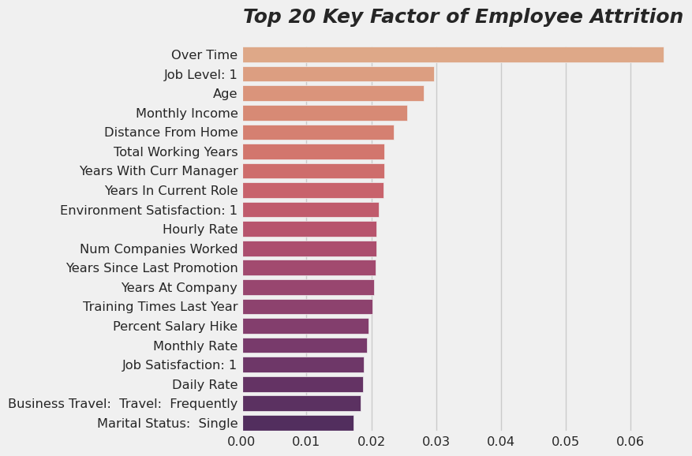

```python
# set plot size
plt.figure(figsize = (9, 6))

# plotting the feature importances
data = feat_importances.sort_values(['Importance'], ascending = False).iloc[:20] # top 20
sns.barplot(y = 'Feature_Display', x = 'Importance', data = data, palette = 'flare')
plt.title('Top 20 Key Factor of Employee Attrition', fontstyle = 'italic', fontweight = 'bold', fontsize = 18, pad = 20)
plt.xlabel('') # clear label
plt.ylabel('') # clear label

plt.tight_layout()
plt.show()
```

Overtime sangat penting dalam pertimbangan attrition karyawan, sangat jauh berbeda dengan feature lainnya.

Kami akan membuat model untuk memprediksi attrition karyawan dengan feature yang memiliki skala feature importance lebih besar dari 0,02.

Serta ditambahkan feature:

- `Department_Sales`
- `Department_ResearchAndDevelopment`
- `Department_HumanResources`
- `JobSatisfaction_1`
- `RelationshipSatisfaction_1`

```python
# filtering features
selected_features = list(feat_importances.loc[feat_importances['Importance'] >= 0.02]['Feature'])
add_features1 = ['Department_Sales', 'Department_Research & Development', 'Department_Human Resources', 'JobSatisfaction_1', 'RelationshipSatisfaction_1']
add_features2 = ['GroupAge_18-30', 'GroupAge_31-40', 'GroupAge_41-50', 'GroupAge_51-60', 'BelowMedIncome', 'GroupAge_Overtime', 'JobLevel_Overtime', 'JobLevel_BelowMedIncome_Overtime']
```

```python
# data clean dan validation semua feature
df_clean_all = df_clean.copy()
df_valid_all = df_unseen.copy()

# data clean dan validation yang isinya feature importance > 0.02 dan tambahan feature kesepakatan kelompok
df_clean_selected = df_clean[['Attrition']].join(df_clean[selected_features + add_features1])
df_valid_selected = df_unseen[['Attrition']].join(df_unseen[selected_features + add_features1])

# data clean dan validation yang isinya feature importance > 0.02, tambahan feature kesepakatan kelompok, dan tambahan feature baru (group age, dll)
df_clean_selected_new = df_clean[['Attrition']].join(df_clean[selected_features + add_features1 + add_features2])
df_valid_selected_new = df_unseen[['Attrition']].join(df_unseen[selected_features + add_features1 + add_features2])
```

```python
# cek tipe data kategorik
df[qual].dtypes
```

```
Attrition                   object
BusinessTravel              object
Department                  object
EducationField              object
EmployeeNumber               int64
Gender                      object
JobRole                     object
MaritalStatus               object
Over18                      object
OverTime                    object
Education                    int64
EnvironmentSatisfaction      int64
JobInvolvement               int64
JobLevel                     int64
JobSatisfaction              int64
PerformanceRating            int64
RelationshipSatisfaction     int64
StockOptionLevel             int64
WorkLifeBalance              int64
dtype: object
```

```python
df['Department'].value_counts()
```

```
Department
Research & Development    961
Sales                     446
Human Resources            63
Name: count, dtype: int64
```

```python
df_imp = df.copy()

df_imp['BusinessTravel'] = df_imp['BusinessTravel'].map({'Non-Travel' : 0, 'Travel_Rarely' : 1, 'Travel_Frequently' : 2})
df_imp['Gender'] = df_imp['Gender'].map({'Male' : 0, 'Female' : 1})
df_imp['OverTime'] = df_imp['OverTime'].map({'No' : 0, 'Yes' : 1})
df_imp['MaritalStatus'] = df_imp['MaritalStatus'].map({'Single' : 0, 'Married' : 1, 'Divorced' : 2})

df_imp['EducationField'] = df_imp['EducationField'].astype('category').cat.codes
df_imp['JobRole'] = df_imp['JobRole'].astype('category').cat.codes

df_imp = df_imp.drop(['Over18', 'EmployeeNumber'], axis = 1)
```

```python
# cek tipe data setelah encoding
df_imp.dtypes
```

```
Age                          int64
Attrition                   object
BusinessTravel               int64
DailyRate                    int64
Department                  object
DistanceFromHome             int64
Education                    int64
EducationField                int8
EmployeeCount                int64
EnvironmentSatisfaction      int64
Gender                       int64
HourlyRate                   int64
JobInvolvement               int64
JobLevel                     int64
JobRole                       int8
JobSatisfaction              int64
MaritalStatus                int64
MonthlyIncome                int64
MonthlyRate                  int64
NumCompaniesWorked           int64
OverTime                     int64
PercentSalaryHike            int64
PerformanceRating            int64
RelationshipSatisfaction     int64
StandardHours                int64
StockOptionLevel             int64
TotalWorkingYears            int64
TrainingTimesLastYear        int64
WorkLifeBalance              int64
YearsAtCompany               int64
YearsInCurrentRole           int64
YearsSinceLastPromotion      int64
YearsWithCurrManager         int64
dtype: object
```

```python
df_imp['Department'].nunique()
```

```
3
```

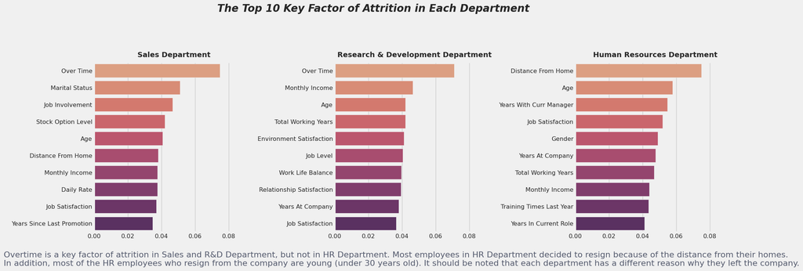

```python
dept_unique = df_imp['Department'].unique()

fig = plt.figure(figsize = (20, 6))

for i in range(0, len(dept_unique)):
    x = df_imp.loc[df_imp['Department'] == dept_unique[i]].drop(['Attrition', 'Department'], axis = 1) # feature
    y = df_imp.loc[df_imp['Department'] == dept_unique[i]]['Attrition'] # target

    feat_importance = ExtraTreesClassifier().fit(x, y).feature_importances_

    feat_imp = pd.DataFrame({'column' : x.columns, 'value' : feat_importance}).sort_values('value', ascending = False).reset_index(drop = True)
    feat_imp['column'] = feat_imp['column'].apply(lambda x: " ".join(re.findall('[A-Z][^A-Z]*', x)))

    plt.subplot(1, 3, i+1)
    sns.barplot(y = 'column', x = 'value', data = feat_imp.iloc[0:10], palette = 'flare')

    plt.title(f"{df_imp['Department'].unique()[i]} Department", fontweight = 'bold', fontsize = 14)
    plt.xlabel('')
    plt.ylabel('')
    plt.xlim(0.0, 0.095)

fig.suptitle("The Top 10 Key Factor of Attrition in Each Department", fontstyle = 'italic', fontweight = 'bold', fontsize = 20, y = 1.1)
fig.text(x = 0, y = -0.05, s = "Overtime is a key factor of attrition in Sales and R&D Department, but not in HR Department. Most employees in HR Department decided to resign because of the distance from their homes. \nIn addition, most of the HR employees who resign from the company are young (under 30 years old). It should be noted that each department has a different reason why they left the company.", ha = 'left', va = 'center_baseline', color = '#555b6e', fontsize = 16)

fig.tight_layout(w_pad = 0.5)

fig.show()
```

# Export Clean Dataset

```python
# # simpan data yang sudah dibersihkan (siap dimodelkan)

# fname_all = 'dataset/data_clean_all.csv'
# fname_selected = 'dataset/data_clean_selected.csv'
# fname_selected_new = 'dataset/data_clean_selected_new.csv'

# fnames = [fname_all, fname_selected, fname_selected_new]
# df_export = [df_clean_all, df_clean_selected, df_clean_selected_new]

# for x_fname, y_df in zip(fnames, df_export):
#     fname = f"{gd_path}/{x_fname}"
#     y_df.to_csv(fname, index = False)
```

```python
# # simpan unseen data

# fname_all = 'dataset/data_valid_all.csv'
# fname_selected = 'dataset/data_valid_selected.csv'
# fname_selected_new = 'dataset/data_valid_selected_new.csv'

# fnames = [fname_all, fname_selected, fname_selected_new]
# df_export = [df_valid_all, df_valid_selected, df_valid_selected_new]

# for x_fname, y_df in zip(fnames, df_export):
#     fname = f"{gd_path}/{x_fname}"
#     y_df.to_csv(fname, index = False)
```

**Taking glance at Columns and Data Types**

```python
# Let's see the list of columns
df.dtypes
```

```
Age                          int64
Attrition                   object
BusinessTravel              object
DailyRate                    int64
Department                  object
DistanceFromHome             int64
Education                    int64
EducationField              object
EmployeeCount                int64
EmployeeNumber               int64
EnvironmentSatisfaction      int64
Gender                      object
HourlyRate                   int64
JobInvolvement               int64
JobLevel                     int64
JobRole                     object
JobSatisfaction              int64
MaritalStatus               object
MonthlyIncome                int64
MonthlyRate                  int64
NumCompaniesWorked           int64
Over18                      object
OverTime                    object
PercentSalaryHike            int64
PerformanceRating            int64
RelationshipSatisfaction     int64
StandardHours                int64
StockOptionLevel             int64
TotalWorkingYears            int64
TrainingTimesLastYear        int64
WorkLifeBalance              int64
YearsAtCompany               int64
YearsInCurrentRole           int64
YearsSinceLastPromotion      int64
YearsWithCurrManager         int64
dtype: object
```

## Calculate Business Metrics **(ATTRITION RATE)**

**Calculate Attrition Rate for ABC Technologies**

> **How to Calculate Employee Turnover Rate?**  
> To calculate employee turnover rate, you’ll need to know, within a given time period, the number of employee separations and the average number of employees present. The average number of employees can be determined by adding together the number of employees on the first day and the last day of the time period, then dividing that sum total by two.

[(Source)](https://builtin.com/recruiting/cost-of-turnover)

Then, plug the above values into the following turnover rate formula:

```
Turnover rate = [(# of employee separations) / (average # of employees)] x 100
```

```python
df_attrition = df[['Attrition', 'JobLevel', 'MonthlyIncome', 'YearsAtCompany']].copy()
df_attrition.head()
```

|  | Attrition | JobLevel | MonthlyIncome | YearsAtCompany |
| --- | --- | --- | --- | --- |
| 0 | Yes | 2 | 5993 | 6 |
| 1 | No | 2 | 5130 | 10 |
| 2 | Yes | 1 | 2090 | 0 |
| 3 | No | 1 | 2909 | 8 |
| 4 | No | 1 | 3468 | 2 |

**Add a column to identify if the employee joined this year**

```python
# is a new employee this year?
ls_jointhisyear = []
for idx, col in df_attrition.iterrows():
    if col['YearsAtCompany'] < 1:
        ls_jointhisyear.append(1) # worked for < 1 year
    else:
        ls_jointhisyear.append(0) # worked for > 1 year

df_attrition['JoinThisYear'] = ls_jointhisyear
df_attrition.head()
```

|  | Attrition | JobLevel | MonthlyIncome | YearsAtCompany | JoinThisYear |
| --- | --- | --- | --- | --- | --- |
| 0 | Yes | 2 | 5993 | 6 | 0 |
| 1 | No | 2 | 5130 | 10 | 0 |
| 2 | Yes | 1 | 2090 | 0 | 1 |
| 3 | No | 1 | 2909 | 8 | 0 |
| 4 | No | 1 | 3468 | 2 | 0 |

**Calculate the Attrition Rate**

```python
employee_start = df_attrition.loc[df_attrition['JoinThisYear'] == 0].shape[0] # the beginning of 2020
employee_end = df_attrition.shape[0] # the end of 2020
employee_avg = (employee_start + employee_end) / 2 # average of employees number in 2020
attrition_total = df_attrition.loc[df_attrition['Attrition'] == 'Yes'].shape[0] # total attrition
turnover_rate = attrition_total / employee_avg # turnover rate

print("Employee Attrition in 2020")
print("--------------------------------------------")

# attrition number in 2020
print(f"Average of Employees Number = {employee_avg:.0f} employees")
print(f"Total Attrition Number = {attrition_total} employees")
# specified for each job level
for i in sorted(df_attrition['JobLevel'].unique()):
    attrition_level = df_attrition.loc[(df_attrition['Attrition'] == 'Yes') & (df_attrition['JobLevel'] == i)].shape[0]
    print(f"  - Job Level {i} = {attrition_level} employees")
print("--------------------------------------------")

# turnover rate in 2020
print(f"Attrition Rate = {turnover_rate:.2%}")
```

```
Employee Attrition in 2020
--------------------------------------------
Average of Employees Number = 1448 employees
Total Attrition Number = 237 employees
  - Job Level 1 = 143 employees
  - Job Level 2 = 52 employees
  - Job Level 3 = 32 employees
  - Job Level 4 = 5 employees
  - Job Level 5 = 5 employees
--------------------------------------------
Attrition Rate = 16.37%
```

Observations:

- The data that we are using for this analysis is from the year 2020.
- The attrition rate in India's technology industry was 6% in 2020
- **The attrition rate of ABC Technologies is 16.37%**

# Exploring The Data (OS**"E"**MN)

## Numeric Approach

### Statistics of Quantitative Data

```python
df_quant.describe()
```

|  | Age | DistanceFromHome | EmployeeCount | NumCompaniesWorked | StandardHours | TrainingTimesLastYear | DailyRate | HourlyRate | MonthlyRate | PercentSalaryHike | TotalWorkingYears | MonthlyIncome | YearsAtCompany | YearsInCurrentRole | YearsSinceLastPromotion | YearsWithCurrManager |
| --- | --- | --- | --- | --- | --- | --- | --- | --- | --- | --- | --- | --- | --- | --- | --- | --- |
| count | 1470.000000 | 1470.000000 | 1470.0 | 1470.000000 | 1470.0 | 1470.000000 | 1470.000000 | 1470.000000 | 1470.000000 | 1470.000000 | 1470.000000 | 1470.000000 | 1470.000000 | 1470.000000 | 1470.000000 | 1470.000000 |
| mean | 36.923810 | 9.192517 | 1.0 | 2.693197 | 80.0 | 2.799320 | 802.485714 | 65.891156 | 14313.103401 | 15.209524 | 11.279592 | 6502.931293 | 7.008163 | 4.229252 | 2.187755 | 4.123129 |
| std | 9.135373 | 8.106864 | 0.0 | 2.498009 | 0.0 | 1.289271 | 403.509100 | 20.329428 | 7117.786044 | 3.659938 | 7.780782 | 4707.956783 | 6.126525 | 3.623137 | 3.222430 | 3.568136 |
| min | 18.000000 | 1.000000 | 1.0 | 0.000000 | 80.0 | 0.000000 | 102.000000 | 30.000000 | 2094.000000 | 11.000000 | 0.000000 | 1009.000000 | 0.000000 | 0.000000 | 0.000000 | 0.000000 |
| 25% | 30.000000 | 2.000000 | 1.0 | 1.000000 | 80.0 | 2.000000 | 465.000000 | 48.000000 | 8047.000000 | 12.000000 | 6.000000 | 2911.000000 | 3.000000 | 2.000000 | 0.000000 | 2.000000 |
| 50% | 36.000000 | 7.000000 | 1.0 | 2.000000 | 80.0 | 3.000000 | 802.000000 | 66.000000 | 14235.500000 | 14.000000 | 10.000000 | 4919.000000 | 5.000000 | 3.000000 | 1.000000 | 3.000000 |
| 75% | 43.000000 | 14.000000 | 1.0 | 4.000000 | 80.0 | 3.000000 | 1157.000000 | 83.750000 | 20461.500000 | 18.000000 | 15.000000 | 8379.000000 | 9.000000 | 7.000000 | 3.000000 | 7.000000 |
| max | 60.000000 | 29.000000 | 1.0 | 9.000000 | 80.0 | 6.000000 | 1499.000000 | 100.000000 | 26999.000000 | 25.000000 | 40.000000 | 19999.000000 | 40.000000 | 18.000000 | 15.000000 | 17.000000 |

Observations:

From the descriptive statistics table above, we can see that:

- There are columns that only have 1 value (not useful for modeling), namely:
  - `EmployeeCount` (always 1)
  - `StandardHours` (always 80)
- There are columns with skewed distribution (the mean value and median value are closely related), namely:
  - `NumCompaniesWorked` (P)
  - `PercentSalaryHike` (P)
  - `TotalWorkingYears` (P)
  - `TrainingTimesLastYear` (N)
  - `YearsAtCompany` (P)
  - `YearsInCurrentRole` (P)
  - `YearsSinceLastPromotion` (P)
  - `YearsWithCurrManager` (P)
  - `DistanceFromHome` (P)
  - `MonthlyIncome` (P)

*Note:*  
*P = positively skewed distribution (mean > median)*  
*N = negatively skewed distribution (mean < median)*

### Statistics of Qualitative Data

```python
# convert Qualititative Data to object (str)
# so that we can use Qualitative Description function .descirbe() to get statistics of Qualitative data
df_qual = df_qual.astype(object)
df_qual.dtypes
df_qual.describe()
```

|  | Attrition | BusinessTravel | Department | EducationField | EmployeeNumber | Gender | JobRole | MaritalStatus | Over18 | OverTime | Education | EnvironmentSatisfaction | JobInvolvement | JobLevel | JobSatisfaction | PerformanceRating | RelationshipSatisfaction | StockOptionLevel | WorkLifeBalance |
| --- | --- | --- | --- | --- | --- | --- | --- | --- | --- | --- | --- | --- | --- | --- | --- | --- | --- | --- | --- |
| count | 1470 | 1470 | 1470 | 1470 | 1470 | 1470 | 1470 | 1470 | 1470 | 1470 | 1470 | 1470 | 1470 | 1470 | 1470 | 1470 | 1470 | 1470 | 1470 |
| unique | 2 | 3 | 3 | 6 | 1470 | 2 | 9 | 3 | 1 | 2 | 5 | 4 | 4 | 5 | 4 | 2 | 4 | 4 | 4 |
| top | No | Travel_Rarely | Research & Development | Life Sciences | 1 | Male | Sales Executive | Married | Y | No | 3 | 3 | 3 | 1 | 4 | 3 | 3 | 0 | 3 |
| freq | 1233 | 1043 | 961 | 606 | 1 | 882 | 326 | 673 | 1470 | 1054 | 572 | 453 | 868 | 543 | 459 | 1244 | 459 | 631 | 893 |

```python
df_qual.dtypes
```

```
Attrition                   object
BusinessTravel              object
Department                  object
EducationField              object
EmployeeNumber              object
Gender                      object
JobRole                     object
MaritalStatus               object
Over18                      object
OverTime                    object
Education                   object
EnvironmentSatisfaction     object
JobInvolvement              object
JobLevel                    object
JobSatisfaction             object
PerformanceRating           object
RelationshipSatisfaction    object
StockOptionLevel            object
WorkLifeBalance             object
dtype: object
```

Observations:

### Unique Value Counts (Frequency)

```python
# Counts of unique values in Qualitiative data
for x in qual:
    print(f"Unique Value Counts for Column {x}:")
    print(f"{df_qual[x].value_counts()}\n")
```

```
Unique Value Counts for Column Attrition:
Attrition
No     1233
Yes     237
Name: count, dtype: int64

Unique Value Counts for Column BusinessTravel:
BusinessTravel
Travel_Rarely        1043
Travel_Frequently     277
Non-Travel            150
Name: count, dtype: int64

Unique Value Counts for Column Department:
Department
Research & Development    961
Sales                     446
Human Resources            63
Name: count, dtype: int64

Unique Value Counts for Column EducationField:
EducationField
Life Sciences       606
Medical             464
Marketing           159
Technical Degree    132
Other                82
Human Resources      27
Name: count, dtype: int64

Unique Value Counts for Column EmployeeNumber:
EmployeeNumber
1       1
1391    1
1389    1
1387    1
1383    1
       ..
659     1
657     1
```

[output cut: 98 more lines]

```
Unique Value Counts for Column StockOptionLevel:
StockOptionLevel
0    631
1    596
2    158
3     85
Name: count, dtype: int64

Unique Value Counts for Column WorkLifeBalance:
WorkLifeBalance
3    893
2    344
4    153
1     80
Name: count, dtype: int64
```

Observations:

Several columns that have very dominant unique values (>50%):

- `Attrition` : No = 1233 (83.9%)
- `BusinessTravel` : Travel_Rarely = 1043 (71.0%)
- `Department` : Research & Development = 961 (65.4%)
- `Gender` : Male = 882 (60.0%)
- `OverTime` : No = 1054 (71.7%)
- `JobInvolvement` : 3 = 868 (59.0%)
- `PerformanceRating` : 3 = 1244 (84.6%)
- `WorkLifeBalance` : 3 = 893 (60.7%)

## Graphical Approach

### Univariate Analysis

#### Target Distribution

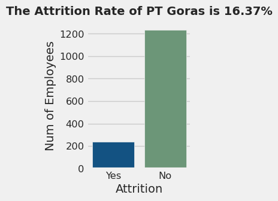

```python
plt.figure(figsize = (2, 3))

sns.countplot(x = 'Attrition', data = df, palette = ['#005495', '#659D75'])

# palette = 'coolwarm'
plt.title('The Attrition Rate of PT Goras is 16.37%', fontweight = 'bold')
plt.xlabel('Attrition')
plt.ylabel('Num of Employees')

plt.show()
```

As expected, the classification target (`Attrition`) has an unequal distribution, where the **attrition rate is 16.37**%.

#### Numerical Feature Distribution (Boxplot)

```python
# check the amount of numeric data
print(f"The amount of numeric data = {len(quant)}")
```

```
The amount of numeric data = 16
```

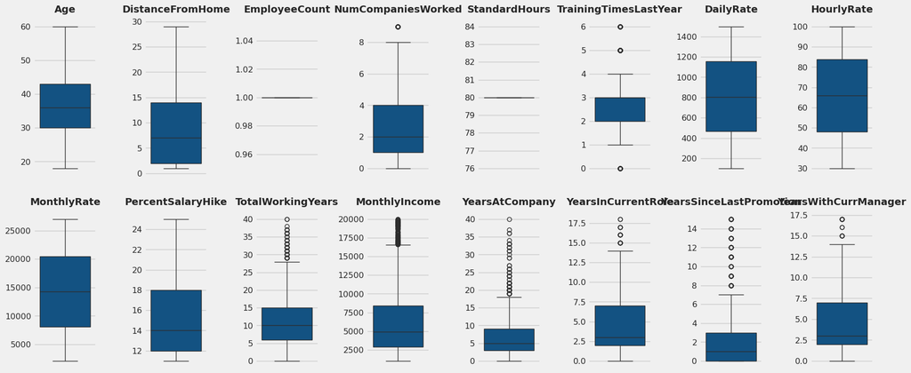

```python
plt.figure(figsize = (18, 8))

for i in range(0, len(quant)):
    plt.subplot(2, 8, i+1)
    sns.boxplot(y = df[quant[i]], color = '#005495', orient = 'v')

    plt.title(quant[i], fontweight = 'bold')
    plt.ylabel('')

plt.tight_layout(pad = 2.0)
plt.show()
```

Observations:

From the box plot above, we can see that:

- There are quite a lot of *outliers* in the column:
  - `TotalWorkingYears`
  - `TrainingTimesLastYear`
  - `YearsAtCompany`
  - `YearsInCurrentRole`
  - `YearsSinceLastPromotion`
  - `YearsWithCurrManager`
  - `MonthlyIncome`
- Most of the columns containing *outliers* are total years of data, meaning that each employee's experience is quite varied.

#### Numerical Feature Distribution (Histogram)

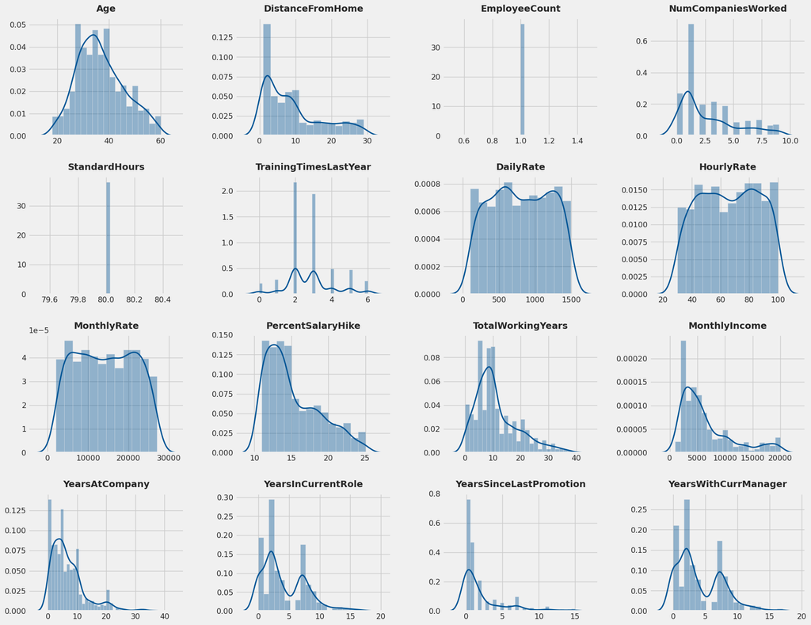

```python
plt.figure(figsize = (18, 14))

for i in range(0, len(quant)):
    plt.subplot(4, 4, i+1)
    sns.distplot(df[quant[i]], color = '#005495')

    plt.title(quant[i], fontweight = 'bold')
    plt.xlabel('')
    plt.ylabel('')

plt.tight_layout(pad = 2.0)
plt.show()
```

Observations:

#### Categorical Feature Distribution (Bar Plot)

```python
# Check the number of columns with Qualitiative data
print(f"Total Qualitative Data = {len(qual)-1}") # target included (need to be removed)
```

```
Total Qualitative Data = 18
```

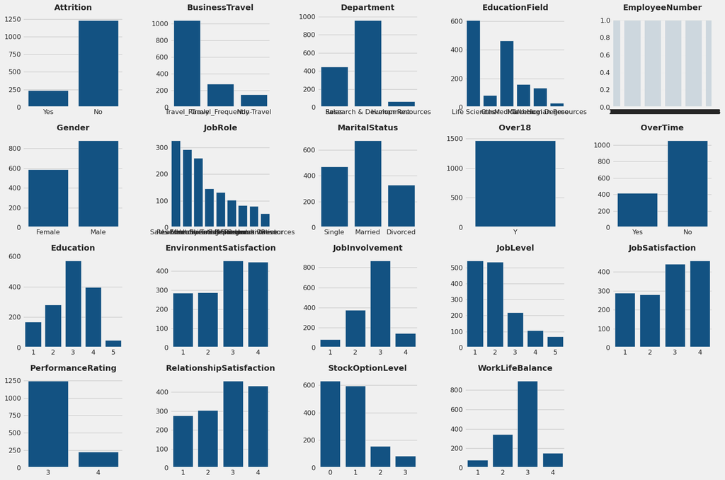

```python
plt.figure(figsize = (18, 12))

for i in range(0, len(qual)):
    plt.subplot(4, 5, i+1)
    #sns.barplot(df[df_qual[i]], color = '#005495')
    sns.countplot(x = qual[i], data = df_qual, color = '#005495', orient = 'v')

    plt.title(qual[i], fontweight = 'bold')
    plt.xlabel('')
    plt.ylabel('')


plt.tight_layout()
plt.show()
```